# A Bayeisan Network Classifier for Acute Myocardial Infarction Microarray

Qing Zhang, Haipeng Wang

November 16, 2017

# 1 Abstract

Polygenic nature of Myocardial infarction poses challenge for clinical diagnosis and prognosis. Here we used whole-genome gene expression micro-array data of 52 samples (data available at GSE48060) to build a Tree-augmented naive Bayesian network classifier that achieve AUC of 0.852. Several attempts were made to integrate biological knowledge-base (e.g. pathways and interactome) into the feature selection process, which did not improve the prediction performance but added to intrepretability of the model.

# 2 Introduction

Coronary disease remains the leading cause of death in adults over 35 years of age in United States(White and Chew 2008). The assessment of risk factors - including hypertension, diabetes and smoking - and the search for molecular markers have gained some success, but they are limited by the existing knowledge. Microarray technology, a robust high-throughput method to screen whole genome expression profile(Korkor et al. 2011), enables search for more sensitive disease marker.

It is assumed that transcriptional speculation of peripheral blood might be a prospective cohort for identify key regulators associated with first-time AMI(Suresh et al. 2014). To devise a pipeline where we can possibly predict the probability of AMI occurrence from non-invasive test (e.g. peripheral blood sample) would be ideal. However microarray data is high dimensional, characterized by many variables and few observations, along with low signal-to-noise ratio, is not ideal for standard machine learning approach(Gevaert et al. 2006).

# 3 Material, Method and Result

## 3.1 Data availability

Data is downloaded from GSE48060. There were 52 samples (31 AMI and 21 controls). AMI peripheral blood sample were collected within 48h of AMI while the control samples are collected following the recruitment to the study. Here is a brief summary of information related to **GSE48060**.

- **channel_count**: 1
- **dataset_id**: *GDS5074* and *GDS5074*
- **description**: *Analysis of circulating blood from first-time acute myocardial infarction (AMI) patients within 48 hours of MI. Results provide insight into molecular mechanisms underlying the response of circulating cells to first-time AMI.*, *acute myocardial infarction* and *normal control*
- **email**: geo@ncbi.nlm.nih.gov
- **feature_count**: 54675
- **institute**: NCBI NLM NIH
- **name**: Gene Expression Omnibus (GEO)
- **order**: none
- **platform**: GPL570
- **platform_organism**: Homo sapiens
- **platform_technology_type**: in situ oligonucleotide
- **pubmed_id**: 24801707
- **ref**: Nucleic Acids Res. 2005 Jan 1;33 Database Issue:D562-6
- **reference_series**: GSE48060
- **sample_count**: 52
- **sample_id**: *GSM1167072,GSM1167073,GSM1167074,GSM1167075,GSM1167076,GSM1167077,GSM1167078,GSM1167079,GSM1167080,GSM1167081,GSM1167082,GSM1167083,GSM1167084,GSM1167085,GSM1167086,GSM1167087,GSM1167088,GSM1167089,GSM1167090,GSM1167091,GSM1167092,GSM1167093,GSM1167094,GSM1167095,GSM1167096,GSM1167097,GSM1167098,GSM1167099,GSM1167100,GSM1167101,GSM1167122* and *GSM1167102,GSM1167103,GSM1167104,GSM1167105,GSM1167106,GSM1167107,GSM1167108,GSM1167109,GSM1167110,GSM1167111,GSM1167112,GSM1167113,GSM1167114,GSM1167115,GSM1167116,GSM1167117,GSM1167118,GSM1167119,GSM1167120,GSM1167121,GSM1167123*
- **sample_organism**: Homo sapiens
- **sample_type**: RNA
- **title**: First-time acute myocardial infarction: peripheral blood
- **type**: *Expression profiling by array*, *disease state* and *disease state*
- **update_date**: Jul 30 2014
- **value_type**: transformed count
- **web_link**: http://www.ncbi.nlm.nih.gov/geo

## 3.2 Statistical analysis of microarray data

A standard pipeline of quality assessment(QA) and quality control(QC) has been carried out, including MA-plot, assessment of raw microarray images, relative log expression. The expression set is normalized using `GCRMA` package(Wu and James MacDonald Jeff Gentry 2017). Gene filtering(Gentleman et al. 2017) was performed subsequently to remove duplicated genes and genes that have low variance or consistent low signal.

### 3.2.1 Clustering

Clustering is a unsupervised method to see if the dataset is ‘learnable’. Here we employed PCA and tSNE for dimension reduction and the two sets shows some mild divergence. This indicates the fold change between the two sets of sample may not be very significant.

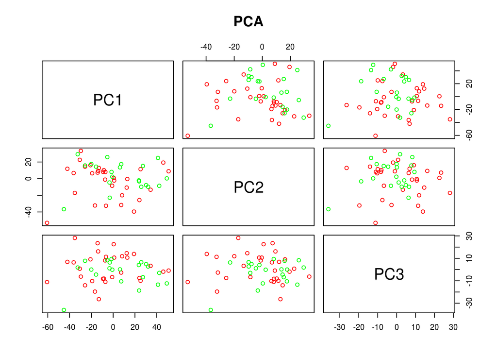

Figure.1 Dimmension reduction by PCA

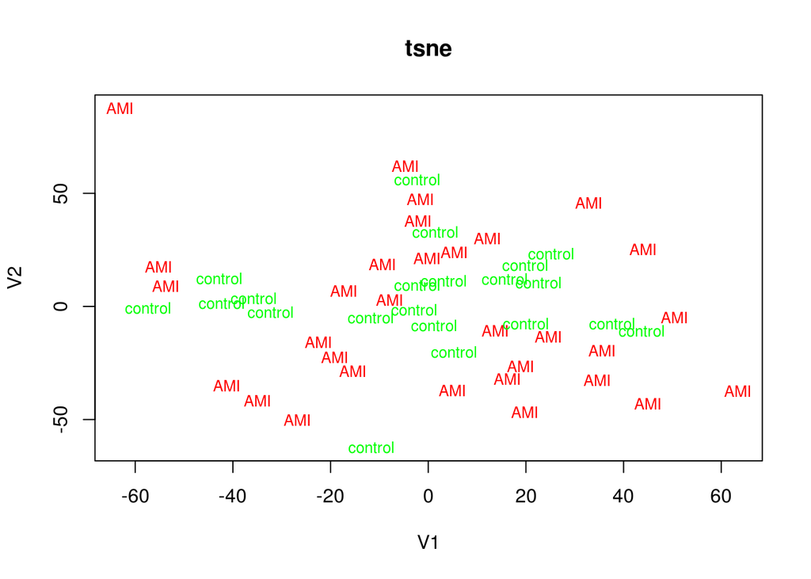

Figure.2 Dimmenssion reduction by tSNE

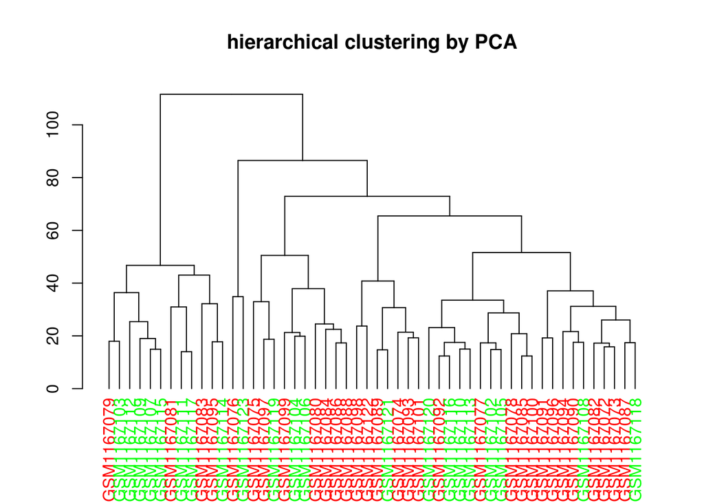

Figure.3 Clustering by PCA

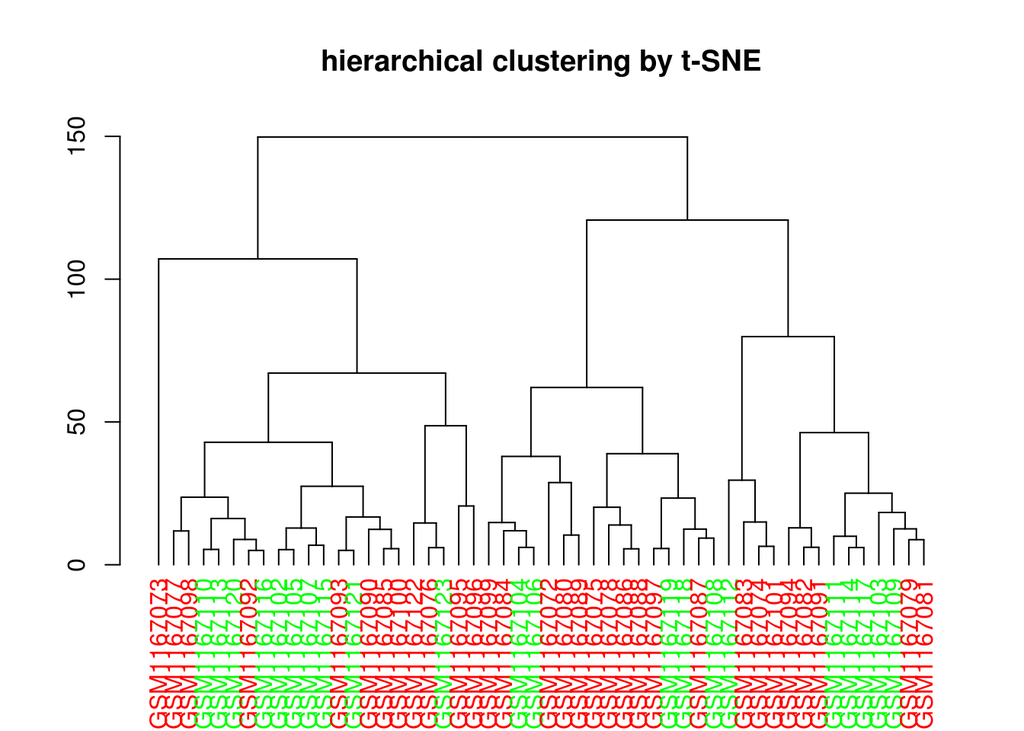

Figure.4 Clustering by tSNE

### 3.2.2 Differential expression analysis

Table.1 Differentially expressed genes

| logFC | P.Value | ENTREZID | GENENAME | SYMBOL | PROBEID |
| --- | --- | --- | --- | --- | --- |
| -0.7930151 | 2.0e-07 | 10181 | RNA binding motif protein 5 | RBM5 | 230742_at |
| 0.8925842 | 2.0e-07 | 6205 | ribosomal protein S11 | RPS11 | 213350_at |
| -0.6341370 | 4.0e-07 | 9910 | RAB GTPase activating protein 1 like | RABGAP1L | 215342_s_at |
| -0.7192016 | 8.0e-07 | 256356 | glycerol kinase 5 (putative) | GK5 | 238121_at |
| 0.7503010 | 1.5e-06 | 2348 | folate receptor 1 | FOLR1 | 211074_at |
| -0.7074877 | 1.7e-06 | 57493 | heart development protein with EGF like domains 1 | HEG1 | 213069_at |

[interactive chart not shown]

Figure.5 A Bicluster heatmap for up- and down-regulated genes between two groups

### 3.2.3 Enrichment analysis

Here Gene ontology and pathway enrichment are performed. Despite ORA-based method is widely adopted by practitioners when conducting GO enrichment tests, FC and topology-based methods are two additional algorithm for pathway enrichment. Here we use `gprofiler` (Reimand, Kolde, and Arak 2016) as ORA-based query and identified the following enriched ontologies terms -

Table.2 GO ontologies enrichment analysis by gprofiler API

| term.id | p.value | term.name |
| --- | --- | --- |
| GO:0002376 | 0e+00 | immune system process |
| GO:0002252 | 3e-07 | immune effector process |
| GO:0002443 | 0e+00 | leukocyte mediated immunity |
| GO:0002444 | 1e-07 | myeloid leukocyte mediated immunity |
| GO:0002446 | 0e+00 | neutrophil mediated immunity |
| GO:0006952 | 1e-07 | defense response |
| GO:0006955 | 0e+00 | immune response |
| GO:0046903 | 5e-07 | secretion |
| GO:0001775 | 0e+00 | cell activation |
| GO:0045321 | 6e-07 | leukocyte activation |
| GO:0002274 | 0e+00 | myeloid leukocyte activation |
| GO:0036230 | 0e+00 | granulocyte activation |
| GO:0042119 | 0e+00 | neutrophil activation |
| GO:0002263 | 0e+00 | cell activation involved in immune response |
| GO:0002366 | 0e+00 | leukocyte activation involved in immune response |
| GO:0002275 | 2e-07 | myeloid cell activation involved in immune response |
| GO:0002283 | 1e-07 | neutrophil activation involved in immune response |
| GO:0006887 | 5e-07 | exocytosis |
| GO:0045055 | 4e-07 | regulated exocytosis |
| GO:0043299 | 2e-07 | leukocyte degranulation |
| GO:0043312 | 1e-07 | neutrophil degranulation |
| GO:0044433 | 0e+00 | cytoplasmic vesicle part |
| GO:0099503 | 3e-07 | secretory vesicle |
| GO:0030141 | 1e-07 | secretory granule |
| REAC:168256 | 8e-07 | Immune System |

Pathway enrichment (based on Reactome) are analysed by both FC(Yu and He 2016) and SPIA(Tarca, Kathri, and Draghici 2013). But the result somehow divergent. Here is the result obtained from ORA methods.

Table.3 Pathway enrichment

| Pathway identifier | Pathway name | Entities pValue | Entities FDR |
| --- | --- | --- | --- |
| R-HSA-6798695 | Neutrophil degranulation | 0.0000044 | 0.0033829 |
| R-HSA-6783783 | Interleukin-10 signaling | 0.0000187 | 0.0072215 |
| R-HSA-168256 | Immune System | 0.0000744 | 0.0192078 |
| R-HSA-449147 | Signaling by Interleukins | 0.0005285 | 0.1020044 |
| R-HSA-6785807 | Interleukin-4 and 13 signaling | 0.0008032 | 0.1143428 |
| R-HSA-1280215 | Cytokine Signaling in Immune system | 0.0008864 | 0.1143428 |
| R-HSA-380108 | Chemokine receptors bind chemokines | 0.0035303 | 0.3630122 |
| R-HSA-432030 | Transport of glycerol from adipocytes to the liver by Aquaporins | 0.0037814 | 0.3630122 |
| R-HSA-5694530 | Cargo concentration in the ER | 0.0054805 | 0.4219981 |
| R-HSA-75108 | Activation, myristolyation of BID and translocation to mitochondria | 0.0065916 | 0.4614087 |